# Tutorial 01_01: Statistica descrittiva e esplorazione dei dati

Corrado Caudek

Modifica i seguenti blocchi di codice e poi esegui (`knit`) ciascun blocco di codice singolarmente, uno dopo l’altro.

```r
library("tidyverse")
```

## Usare R come un calcolatore

Nella console, digita le seguenti istruzioni:

```
1 + 2
a <- 1
b <- 2
a + b
```

Lo stesso risultato si ottiene mediante il seguente blocco di codice in questo documento Rmd:

```r
1 + 2
```

```
## [1] 3
```

```r
a <- 1
b <- 2
a + b
```

```
## [1] 3
```

## Media

Consideriamo ora i valori BDI-II dello studio di Zetsche, Bürkner, e Renneberg (2019) che sono discussi nelle dispense e sono riportati qui di seguito:

```r
bdi <- c(
  0,  0, 0,  0,  0,  0,  0,  0,  0,  0,  0,  0,  0,  0,  0,  0,
  0,  1,  1,  1,  1,  1,  1,  1,  1,  2,  2,  2,  2, 3,  3,  3,
  5,  7,  9, 12, 19, 22, 22, 24, 25, 25, 26, 26, 26, 27, 27, 28,
  28, 30, 30, 30, 31, 31, 33, 33, 34, 35, 35, 35, 36, 39, 41,
  43, 43, 44
)
```

Si utilizzi la funzione appropriata per stabilire di quanti elementi è composto il vettore `bdi`.

```r
# inserisci il codice qui
length(bdi)
```

```
## [1] 66
```

Si utilizzi la funzione appropriata per trovare il valore della somma dei valori del vettore `bdi`.

```r
# inserisci il codice qui
sum(bdi)
```

```
## [1] 986
```

Si noti che questa istruzione $\textsf{R}$ esegue l’operazione descritta nella seguente notazione:

$$\begin{equation}
\begin{split}
\sum_{i =1}^{n=66} X_i &= X_1 + X_2 + \dots + X_{65} + X_{66} \\
&= 0 + 0 + \dots + 43 + 44 \\ &= 986
\end{split}
\end{equation}$$

La media è data dalla somma dei valori divisa per il numero dei casi. Mediante le due funzioni utilizzate sopra, si calcoli la media:

$$\bar{X} = \frac{\sum_{i =1}^{n} X_i}{n}$$

```r
# inserisci il codice qui
sum(bdi) / length(bdi)
```

```
## [1] 14.93939
```

Si confronti il risultato ottenuto con quello prodotto dalla funzione `mean()`:

```r
# inserisci il codice qui
mean(bdi)
```

```
## [1] 14.93939
```

## Istogramma

Poniamoci ora il problema di creare un istogramma con i valori `bdi`. Per semplicità useremo la funzione `hist()` di R base – in seguito costruiremo l’istogramma con `ggplot()`. Iniziamo ad esaminare il file di help:

```r
?hist
```

Per i nostri scopi, dobbiamo capire come passare il vettore `bdi` in input a `hist()`. Il file di help ci dice che la sintassi è `hist(bdi)`.

Ma questo non è sufficiente, in quanto un istogramma può essere costruito in molti modi diversi, per cui dobbiamo capire come l’istogramma viene costruito da $\textsf{R}$ mediante la funzione `hist()` di default (ovvero, senza altre specificazioni).

Nel file di help, l’argomento `freq` viene descritto come segue:

> freq logical; if TRUE, the histogram graphic is a representation of frequencies, the counts component of the result; if FALSE, probability densities, component density, are plotted (so that the histogram has a total area of one).

Da ciò deduciamo che dobbiamo porre `freq = FALSE` per ottenere un istogramma che abbia un’area totale uguale a 1, ovvero per ottenere quello che chiede il problema successivo.

**Problema:** Utilizzando la funzione `hist()` si crei un istogramma tale che la somma delle aree delle barre dell’istogramma sia uguale a 1:

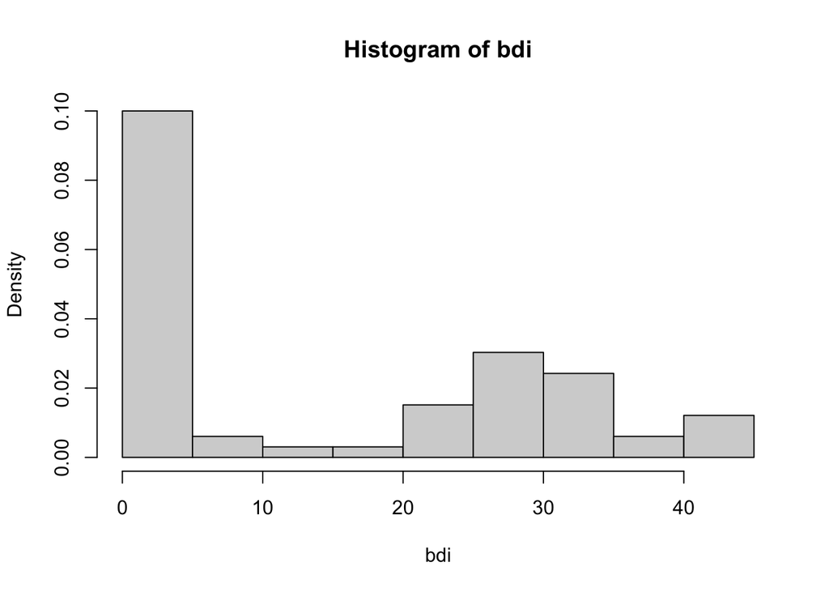

```r
# inserisci il codice qui
hist(bdi, freq = FALSE)
```

Esaminiamo i dati che sono stati utilizzati dalla funzione `hist()` per creare l’istogramma.

```r
out <- hist(bdi, freq = FALSE, plot = FALSE)
out
```

```
## $breaks
##  [1]  0  5 10 15 20 25 30 35 40 45
##
## $counts
## [1] 33  2  1  1  5 10  8  2  4
##
## $density
## [1] 0.100000000 0.006060606 0.003030303 0.003030303 0.015151515 0.030303030
## [7] 0.024242424 0.006060606 0.012121212
##
## $mids
## [1]  2.5  7.5 12.5 17.5 22.5 27.5 32.5 37.5 42.5
##
## $xname
## [1] "bdi"
##
## $equidist
## [1] TRUE
##
## attr(,"class")
## [1] "histogram"
```

Dal file di help della funzione scopriamo che, di default,

- include.lowest = TRUE

“if TRUE, an x[i] equal to the breaks value will be included in the first (or last, for right = FALSE) bar. This will be ignored (with a warning) unless breaks is a vector.”

- right = TRUE

Questo significa che `hist()` utilizza (di default) intervalli chiusi a destra e aperti a sinistra: $( \; ]$. In altre parole, un valore che coincide con il limite inferiore sarà escluso dall’intervallo, mentre un valore che coincide con il limite superiore sarà incluso nell’intervallo.

La funzione `hist()` utilizza di default i limiti degli intervalli specificati da $breaks – questo si può cambiare, ma per ora non lo facciamo.

Esaminiamo il secondo intervallo, ovvero (5, 10]. Chiediamoci la seguente domanda: quanti valori del vettore `bdi` sono compresi nell’intervallo (5, 10]?

Per rispondere a questa domanda dobbiamo esaminare la sequenza ordinata dei valori `bdi`. Se ci focalizziamo sui valori che ci interessano (… 3 5 7 9 12 …), allora vediamo che, tra i possibili candidati il valore 5 coincide con il limite inferiore dell’intervallo. Ma, dato che l’intervallo è aperto a sinistra, il valore 5 non sarà incluso nell’intervallo. Quindi restano solo due valori possibili: 7 e 9. La frequenza assoluta associata al secondo intervallo è dunque pari a 2. Questo è indicato dal secondo valore di $counts.

In maniera corrispondente, possiamo calcolare il numero di osservazioni contenute nell’intervallo (20, 25], ovvero $20 < x \leq 25$:

```r
length(bdi[bdi > 20 & bdi <= 25])
```

```
## [1] 5
```

Si calcoli ora la densità della seconda barra dell’istogramma. (Suggerimento: ricordiamo che l’area della seconda barra dell’istogramma è uguale alla frequenza relativa della seconda classe e che la densità della seconda barra è semplicemente l’altezza della barra).

```r
# inserisci il codice qui
(length(bdi[bdi > 5 & bdi <= 10]) / length(bdi)) / 5
```

```
## [1] 0.006060606
```

Si può vedere che il valore trovato coincide con il secondo valore di $density.

Ripetiamo la procedura per l’ultima barra dell’istogramma. La densità dell’ultima barra dell’istogramma è

```r
# inserisci il codice qui
(length(bdi[bdi > 40 & bdi <= 45]) / length(bdi)) / 5
```

```
## [1] 0.01212121
```

Questo risultato coincide con l’ultimo valore di $density.